# Lab 03 - Exploratory Data Analysis

January 22, 2025

# Learning Goals

- Read in and get familiar with the meteorology dataset
- Step through the EDA “checklist” presented in the class slides
- Practice making exploratory graphs

# Lab Description

We will work with the meteorological data presented in lecture. Recall the dataset consists of weather station readings in the contiguous US.

**The objective of the lab is to find the weather station with the highest elevation and look at patterns in the time series of its wind speed and temperature.**

# Steps

### 1. Read in the data

First download and then read in with `data.table` function `fread()`

```r
download.file(
  "https://raw.githubusercontent.com/JSC370/JSC370-2025/main/data/met/met_all.gz",
  destfile = "met_all.gz",
  method   = "curl",
  timeout  = 60
  )

met <- data.table::fread("met_all.gz")
```

### 2. Check the dimensions, headers, footers. How many columns, rows are there?

- Note you may use R or Python

```r
# dimension
cat("Dimension:", dim(met), "\n")
```

```
## Dimension: 2377343 30
```

```r
# row
cat("Row:", nrow(met), "\n")
```

```
## Row: 2377343
```

```r
# col
cat("Col:", ncol(met), "\n")
```

```
## Col: 30
```

```r
# headers
print(head(met))
```

```
##    USAFID  WBAN  year month   day  hour   min   lat      lon  elev wind.dir
##     <int> <int> <int> <int> <int> <int> <int> <num>    <num> <int>    <int>
## 1: 690150 93121  2019     8     1     0    56  34.3 -116.166   696      220
## 2: 690150 93121  2019     8     1     1    56  34.3 -116.166   696      230
## 3: 690150 93121  2019     8     1     2    56  34.3 -116.166   696      230
## 4: 690150 93121  2019     8     1     3    56  34.3 -116.166   696      210
## 5: 690150 93121  2019     8     1     4    56  34.3 -116.166   696      120
## 6: 690150 93121  2019     8     1     5    56  34.3 -116.166   696       NA
##    wind.dir.qc wind.type.code wind.sp wind.sp.qc ceiling.ht ceiling.ht.qc
##         <char>         <char>   <num>     <char>      <int>         <int>
## 1:           5              N     5.7          5      22000             5
## 2:           5              N     8.2          5      22000             5
## 3:           5              N     6.7          5      22000             5
## 4:           5              N     5.1          5      22000             5
## 5:           5              N     2.1          5      22000             5
```

[output cut: 17 more lines]

```r
# footers
print(tail(met))
```

```
##    USAFID  WBAN  year month   day  hour   min    lat      lon  elev wind.dir
##     <int> <int> <int> <int> <int> <int> <int>  <num>    <num> <int>    <int>
## 1: 726813 94195  2019     8    31    18    56 43.650 -116.633   741       NA
## 2: 726813 94195  2019     8    31    19    56 43.650 -116.633   741       70
## 3: 726813 94195  2019     8    31    20    56 43.650 -116.633   741       NA
## 4: 726813 94195  2019     8    31    21    56 43.650 -116.633   741       10
## 5: 726813 94195  2019     8    31    22    56 43.642 -116.636   741       10
## 6: 726813 94195  2019     8    31    23    56 43.642 -116.636   741       40
##    wind.dir.qc wind.type.code wind.sp wind.sp.qc ceiling.ht ceiling.ht.qc
##         <char>         <char>   <num>     <char>      <int>         <int>
## 1:           9              C     0.0          5      22000             5
## 2:           5              N     2.1          5      22000             5
## 3:           9              C     0.0          5      22000             5
## 4:           5              N     2.6          5      22000             5
## 5:           1              N     2.1          1      22000             1
```

[output cut: 17 more lines]

The dimension the dataset is (2377343, 30) with 2377343 rows and 30 columns. Based on the headers and the footers, there can be more than one observation in the same place and in the same day.

### 3. Take a look at the variables in the dataset. What kind of variables are there?

```r
str(met)
```

```
## Classes 'data.table' and 'data.frame':   2377343 obs. of  30 variables:
##  $ USAFID           : int  690150 690150 690150 690150 690150 690150 690150 690150 690150 690150 ...
##  $ WBAN             : int  93121 93121 93121 93121 93121 93121 93121 93121 93121 93121 ...
##  $ year             : int  2019 2019 2019 2019 2019 2019 2019 2019 2019 2019 ...
##  $ month            : int  8 8 8 8 8 8 8 8 8 8 ...
##  $ day              : int  1 1 1 1 1 1 1 1 1 1 ...
##  $ hour             : int  0 1 2 3 4 5 6 7 8 9 ...
##  $ min              : int  56 56 56 56 56 56 56 56 56 56 ...
##  $ lat              : num  34.3 34.3 34.3 34.3 34.3 34.3 34.3 34.3 34.3 34.3 ...
##  $ lon              : num  -116 -116 -116 -116 -116 ...
##  $ elev             : int  696 696 696 696 696 696 696 696 696 696 ...
##  $ wind.dir         : int  220 230 230 210 120 NA 320 10 320 350 ...
##  $ wind.dir.qc      : chr  "5" "5" "5" "5" ...
##  $ wind.type.code   : chr  "N" "N" "N" "N" ...
##  $ wind.sp          : num  5.7 8.2 6.7 5.1 2.1 0 1.5 2.1 2.6 1.5 ...
```

[output cut: 17 more lines]

### 4. Take a closer look at the key variables.

- Are there missing data? If so, make sure they are coded correctly.
- Are there any unusual values that look suspicious? Recall the temperature values in the lecture.

```r
# The dataset only contains "2019"
table(met$year)
```

```
##
##    2019
## 2377343
```

```r
# The dataset contains day from 1 to 31
table(met$day)
```

```
##
##     1     2     3     4     5     6     7     8     9    10    11    12    13
## 75975 75923 76915 76594 76332 76734 77677 77766 75366 75450 76187 75052 76906
##    14    15    16    17    18    19    20    21    22    23    24    25    26
## 77852 76217 78015 78219 79191 76709 75527 75786 78312 77413 76965 76806 79114
##    27    28    29    30    31
## 79789 77059 71712 74931 74849
```

```r
# Hour starts from 0 to 23
table(met$hour)
```

```
##
##      0      1      2      3      4      5      6      7      8      9     10
##  99434  93482  93770  96703 110504 112128 106235 101985 100310 102915 101880
##     11     12     13     14     15     16     17     18     19     20     21
## 100470 103605  97004  96507  97635  94942  94184 100179  94604  94928  96070
##     22     23
##  94046  93823
```

```r
summary(met$temp)
```

```
##    Min. 1st Qu.  Median    Mean 3rd Qu.    Max.    NA's
##  -40.00   19.60   23.50   23.59   27.80   56.00   60089
```

```r
summary(met$elev)
```

```
##    Min. 1st Qu.  Median    Mean 3rd Qu.    Max.
##   -13.0   101.0   252.0   415.8   400.0  9999.0
```

```r
summary(met$wind.sp)
```

```
##    Min. 1st Qu.  Median    Mean 3rd Qu.    Max.    NA's
##    0.00    0.00    2.10    2.46    3.60   36.00   79693
```

The elevation variable is unusual with value of 9999. We can replace 9999 with NA to indicate missing value.

### 5. Check the data against an external data source and make adjustments.

- Check that the range of elevations make sense.
- Google or ChatGPT is your friend here.
- Fix any problems that arise in your checks.

```r
met$elev[met$elev == 9999] <- NA
summary(met$elev)
```

```
##    Min. 1st Qu.  Median    Mean 3rd Qu.    Max.    NA's
##     -13     101     252     413     400    4113     710
```

```r
table(met$temp == -40, useNA = "always")
```

```
##
##   FALSE    TRUE    <NA>
## 2317218      36   60089
```

```r
sum(is.na(met$temp))
```

```
## [1] 60089
```

```r
met <- met[temp > -40]
sum(is.na(met$temp))
```

```
## [1] 0
```

```r
met <- met[temp > -2]
met2 <- met[order(temp)]
head(unique(met2[,.(lat, lon, elev, temp)]))
```

```
##       lat      lon  elev  temp
##     <num>    <num> <int> <num>
## 1: 44.544 -110.421  2388  -1.7
## 2: 37.633 -118.850  2173  -1.5
## 3: 44.544 -110.421  2388  -1.1
## 4: 36.422 -105.290  2554  -1.0
## 5: 39.320 -120.139  1798  -1.0
## 6: 44.683 -111.116  2025  -1.0
```

I replace the data point with elevation 9999 with NA.

### 6. Calculate summary statistics

Remember to keep the initial question in mind. We want to pick out the weather station with maximum elevation and examine its wind speed and temperature.

Some ideas: 1. select the weather station with maximum elevation; 2. look at the correlation between temperature and wind speed; and 3. look at the correlation between temperature and wind speed with hour and day of the month.

```r
# 1. Weather station with maximum elevation
highest <- met[elev == max(met$elev, na.rm = TRUE)]
summary(highest[, .(elev, lat, lon, temp, wind.sp)])
```

```
##       elev           lat            lon              temp
##  Min.   :4113   Min.   :39.8   Min.   :-105.8   Min.   : 1.00
##  1st Qu.:4113   1st Qu.:39.8   1st Qu.:-105.8   1st Qu.: 6.00
##  Median :4113   Median :39.8   Median :-105.8   Median : 8.00
##  Mean   :4113   Mean   :39.8   Mean   :-105.8   Mean   : 8.13
##  3rd Qu.:4113   3rd Qu.:39.8   3rd Qu.:-105.8   3rd Qu.:10.00
##  Max.   :4113   Max.   :39.8   Max.   :-105.8   Max.   :15.00
##
##     wind.sp
##  Min.   : 0.000
##  1st Qu.: 4.100
##  Median : 6.700
##  Mean   : 7.245
##  3rd Qu.: 9.800
##  Max.   :21.100
##  NA's   :168
```

```r
cor(highest$temp, highest$wind.sp, use="complete")
```

```
## [1] -0.09373843
```

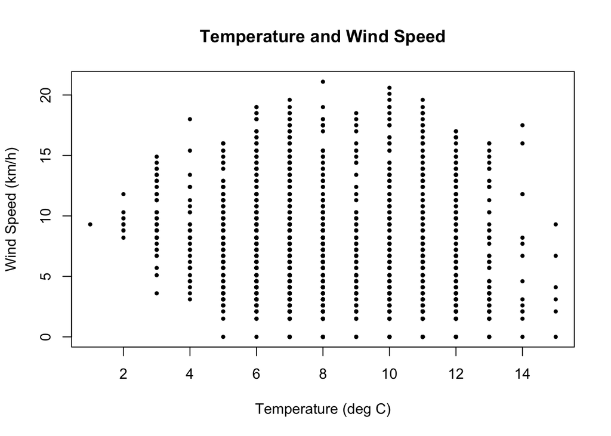

```r
plot(
  x = highest$temp,
  y = highest$wind.sp,
  pch=19,
  cex=0.5,
  main = "Temperature and Wind Speed",
  xlab = "Temperature (deg C)", ylab = "Wind Speed (km/h)")
```

```r
cat("Temperature vs Day:", cor(highest$temp, highest$day, use="complete"), "\n")
```

```
## Temperature vs Day: -0.003857766
```

```r
cat("Temperature vs Hour:", cor(highest$temp, highest$hour, use="complete"), "\n")
```

```
## Temperature vs Hour: 0.4397261
```

```r
cat("Wind Speed vs Day:", cor(highest$wind.sp, highest$day, use="complete"), "\n")
```

```
## Wind Speed vs Day: 0.3643079
```

```r
cat("Wind Speed vs Hour:", cor(highest$wind.sp, highest$hour, use="complete"), "\n")
```

```
## Wind Speed vs Hour: 0.08807315
```

### 7. At what elevation is the highest weather station?

```r
cat("The highest wheather station has an evalation of", unique(highest$elev))
```

```
## The highest wheather station has an evalation of 4113
```

- The highest wheather station has an evalation of 4113

### 8. Exploratory graphs: Distributions

We should look at the distributions of all of the key variables (elevation, temp, wind speed) to make sure there are no remaining issues with the data.

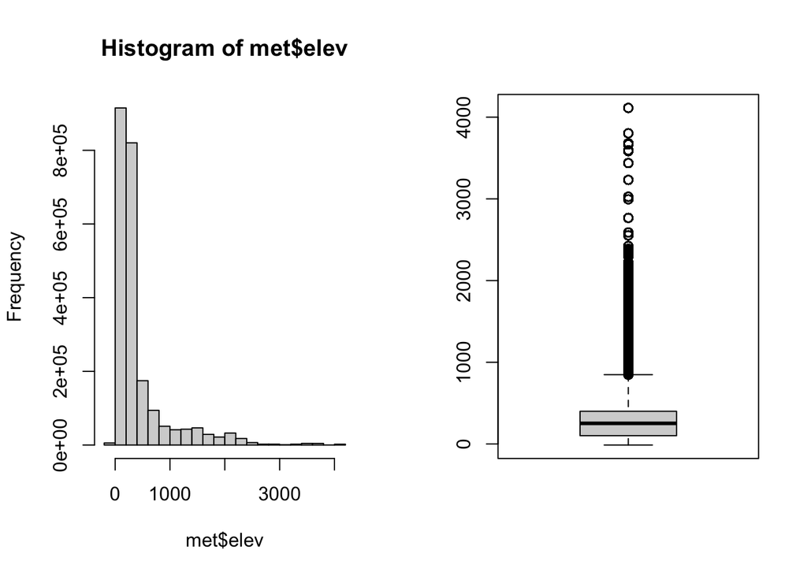

```r
# Distribution of elevation
par(mfrow = c(1, 2))
hist(met$elev)
boxplot(met$elev)
```

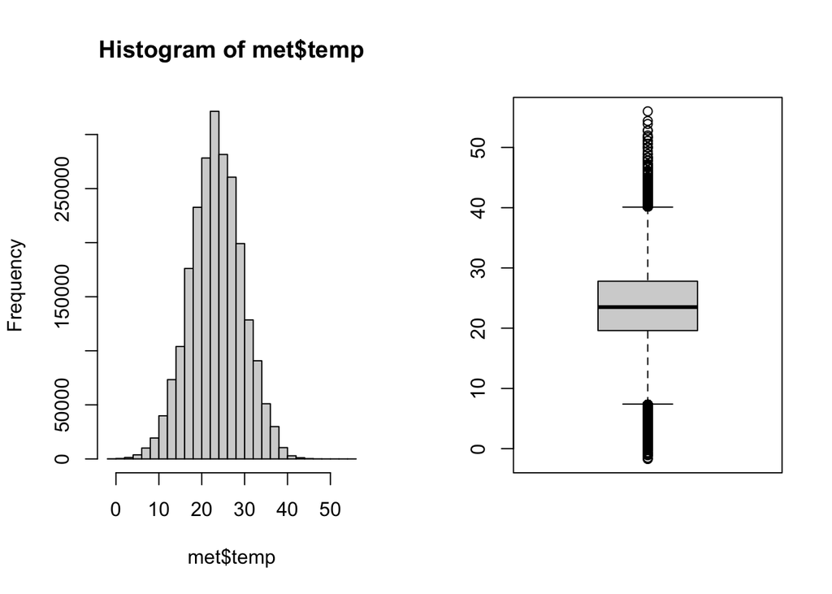

```r
# Distribution of temperature
par(mfrow = c(1, 2))
hist(met$temp)
boxplot(met$temp)
```

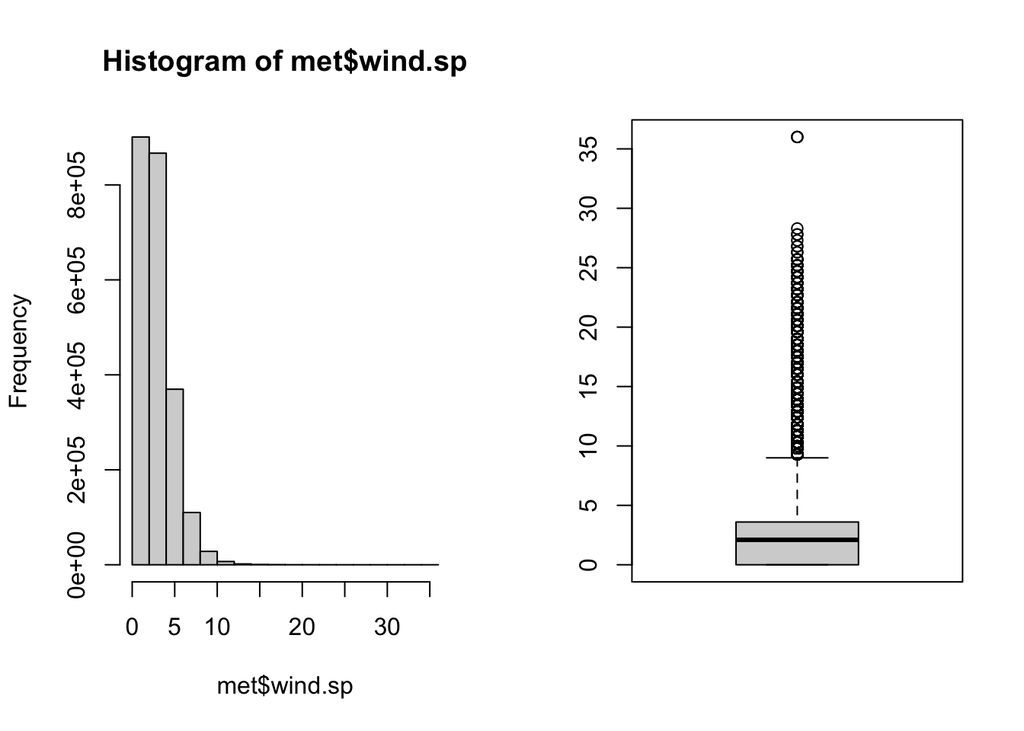

```r
# Distribution of wind speed
par(mfrow = c(1, 2))
hist(met$wind.sp)
boxplot(met$wind.sp)
```

- Wind speed and elevation both are right-skew and have so many outliers.

One thing we should consider for later analyses is to log transform wind speed and elevation as the are very skewed.

### 9. Exploratory graphs: Time Series

Look at the time series of temperature and wind speed at this location. For this we will need to create a date-time variable for the x-axis.

```r
met$date <- with(met, ymd_h(paste(year, month, day, hour, spe="")))
summary(met$date)
```

```
##                       Min.                    1st Qu.
## "2019-08-01 00:00:00.0000" "2019-08-08 18:00:00.0000"
##                     Median                       Mean
## "2019-08-16 12:00:00.0000" "2019-08-16 11:33:41.5497"
##                    3rd Qu.                       Max.
## "2019-08-24 05:00:00.0000" "2019-08-31 23:00:00.0000"
```

```r
met <- met[order(date)]
```

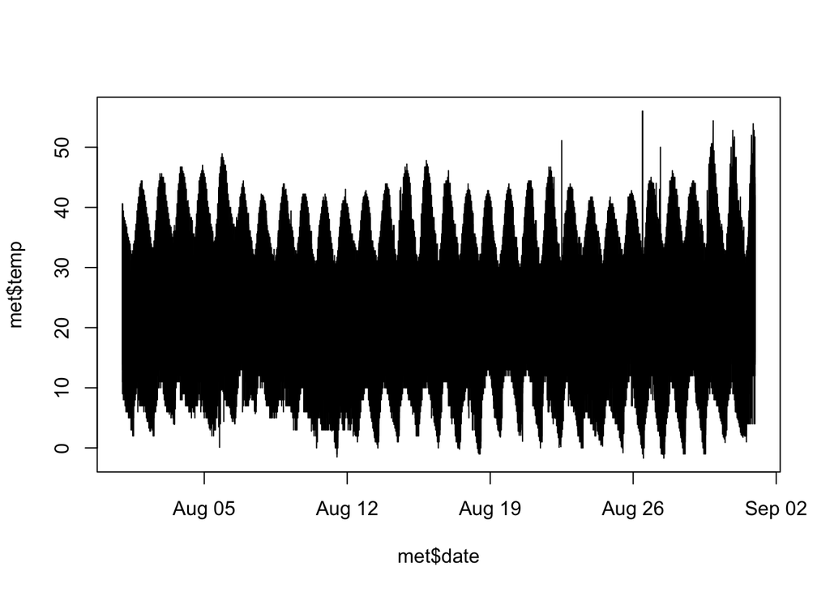

```r
plot(met$date, met$temp, type="l")
```

### 10. Exploratory graphs: Map

Where is the weather station with highest elevation located? (i.e. make a map!)

```r
leaflet(highest) %>%
    addProviderTiles('OpenStreetMap') %>%
    addCircles(lat=~lat, lng=~lon, opacity=1, fillOpacity=1, radius=100)
```

[interactive chart not shown]